# Part II - (Explanatory analysis of Loan Data)

## by (Williams Miebi Gbeneowei)

## Investigation Overview:

This presentation is meant to show factors that affects the outcome of a loan's status and also display the effect of loan term on annual percentage rate(APR) of the borrower.

## Dataset Overview

## DATA SET:

The provided data set consists of several key performance indicators such as borrowerAPR,borrower rate,income range, prosper rating, etc of 113937 loans. And over 80 columns. The key performance indicators are what determines if a prospective borrower will be granted a loan and how many percent interest will charged for the loan and the time duration that will be granted for payment of the loan.

|  | EstimatedReturn | StatedMonthlyIncome | DelinquenciesLast7Years | Term | AmountDelinquent | ProsperScore | EmploymentStatusDuration | CreditScoreRangeLower | CreditScoreRangeUpper | CurrentCreditLines | OpenCreditLines | RevolvingCreditBalance | DebtToIncomeRatio | BorrowerAPR | BorrowerRate | AvailableBankcardCredit | ProsperRating (numeric) | LoanOriginalAmount |
| --- | --- | --- | --- | --- | --- | --- | --- | --- | --- | --- | --- | --- | --- | --- | --- | --- | --- | --- |
| count | 84853.000000 | 1.139120e+05 | 112947.000000 | 113912.000000 | 106315.000000 | 84853.000000 | 106312.000000 | 113346.000000 | 113346.000000 | 106333.000000 | 106333.000000 | 1.063330e+05 | 105358.000000 | 113912.000000 | 113912.000000 | 106393.000000 | 84853.000000 | 113912.000000 |
| mean | 0.096068 | 5.606973e+03 | 4.154984 | 40.831308 | 984.507059 | 5.950067 | 96.071582 | 685.567731 | 704.567731 | 10.317192 | 9.260164 | 1.759871e+04 | 0.275993 | 0.218828 | 0.192786 | 11210.225447 | 4.072243 | 8338.015661 |
| std | 0.030403 | 7.478338e+03 | 10.160216 | 10.437112 | 7158.270157 | 2.376501 | 94.480605 | 66.458275 | 66.458275 | 5.457866 | 5.022644 | 3.293640e+04 | 0.551814 | 0.080364 | 0.074809 | 19818.361309 | 1.673227 | 6245.940592 |
| min | -0.182700 | 0.000000e+00 | 0.000000 | 12.000000 | 0.000000 | 1.000000 | 0.000000 | 0.000000 | 19.000000 | 0.000000 | 0.000000 | 0.000000e+00 | 0.000000 | 0.006530 | 0.000000 | 0.000000 | 1.000000 | 1000.000000 |
| 25% | 0.074080 | 3.200000e+03 | 0.000000 | 36.000000 | 0.000000 | 4.000000 | 26.000000 | 660.000000 | 679.000000 | 7.000000 | 6.000000 | 3.121000e+03 | 0.140000 | 0.156290 | 0.134000 | 880.000000 | 3.000000 | 4000.000000 |
| 50% | 0.091700 | 4.666667e+03 | 0.000000 | 36.000000 | 0.000000 | 6.000000 | 67.000000 | 680.000000 | 699.000000 | 10.000000 | 9.000000 | 8.549000e+03 | 0.220000 | 0.209760 | 0.184000 | 4100.000000 | 4.000000 | 6500.000000 |
| 75% | 0.116600 | 6.817083e+03 | 3.000000 | 36.000000 | 0.000000 | 8.000000 | 137.000000 | 720.000000 | 739.000000 | 13.000000 | 12.000000 | 1.952100e+04 | 0.320000 | 0.283810 | 0.250000 | 13180.000000 | 5.000000 | 12000.000000 |
| max | 0.283700 | 1.750003e+06 | 99.000000 | 60.000000 | 463881.000000 | 11.000000 | 755.000000 | 880.000000 | 899.000000 | 59.000000 | 54.000000 | 1.435667e+06 | 10.010000 | 0.512290 | 0.497500 | 646285.000000 | 7.000000 | 35000.000000 |

## Univariate Exploration

### Borrower APR and Borrower Rate.

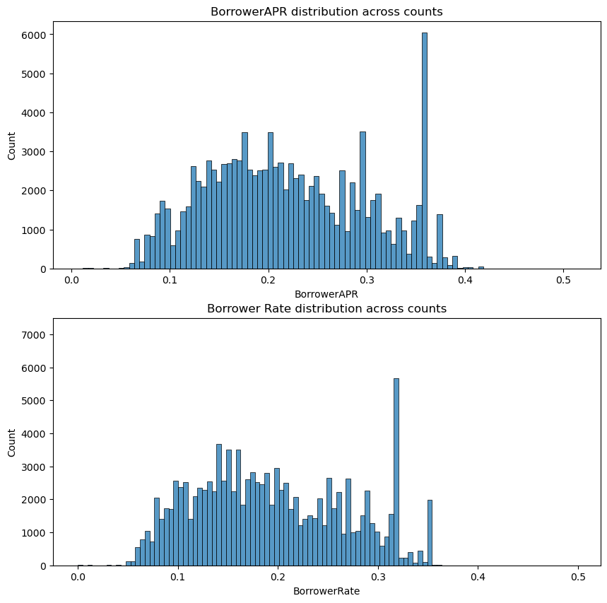